# Text as Data

W10 · Transformers: Architecture and Applications

Yen-Chieh Liao

## Course route

Concepts → Applications → Lab

1**Transformer basics**Tokens → Attention → Representations → Fine-tuning

→

2**Classification**Three studies: oversight, issue attention and stance

→

3**NLI applications**Text + hypothesis → Relation scores → Task labels

→

**Lab**Policy fine-tuning → NLI stance example

**One framework, two ways to turn text into research labels.**

[Vaswani et al. (2017)](https://papers.neurips.cc/paper/7181-attention-is-all-you-need) · [Devlin et al. (2019)](https://aclanthology.org/N19-1423/) · Lab: Liao & Müller (2024), supplied Week 12 notebooks.

← / → Follow the course route

## Transformer basics

**How does a Transformer turn a token sequence into contextual representations?**

1**Build the input**Token IDs → vectors + position information

→

2**Process the context**Self-attention + feed-forward layers

→

3**Reuse the output**Contextual representations learned through pretraining

These representations can support a task classifier.

[Vaswani et al. (2017), §§3.1–3.5](https://papers.neurips.cc/paper/7181-attention-is-all-you-need) · [Devlin et al. (2019), §3](https://aclanthology.org/N19-1423/).

← / → Follow the architecture

## A token is a model input unit

| Text we read | Transformer input |
| --- | --- |
| A word may be the unit of analysis. | A word may be split into several tokens. |
| A passage contains words and punctuation. | Special tokens mark boundaries or tasks. |
| We interpret the original text. | Token IDs index a model’s vocabulary. |

Token IDs → embedding lookup → input vectors.

**Keep the tokenizer matched to the trained model.**

[BERT, §3](https://aclanthology.org/N19-1423/).

← / → Follow the tokens

## Word order is part of the input

My dog is cute. He likes playing.

| Position | 0 | 1 | 2 | 3 | 4 | 5 | 6 | 7 | 8 | 9 | 10 |
| --- | --- | --- | --- | --- | --- | --- | --- | --- | --- | --- | --- |
| Token | [CLS] | my | dog | is | cute | . | he | likes | playing | . | [SEP] |

The bert-base-uncased tokenizer lowercases this input and adds [CLS] and [SEP].

Token vectors + **position information** → input to the encoder.

[Vaswani et al. (2017), §3.5](https://papers.neurips.cc/paper/7181-attention-is-all-you-need); [BERT, Figure 2](https://aclanthology.org/N19-1423/).

← / → Follow the positions

## Self-attention mixes information across positions

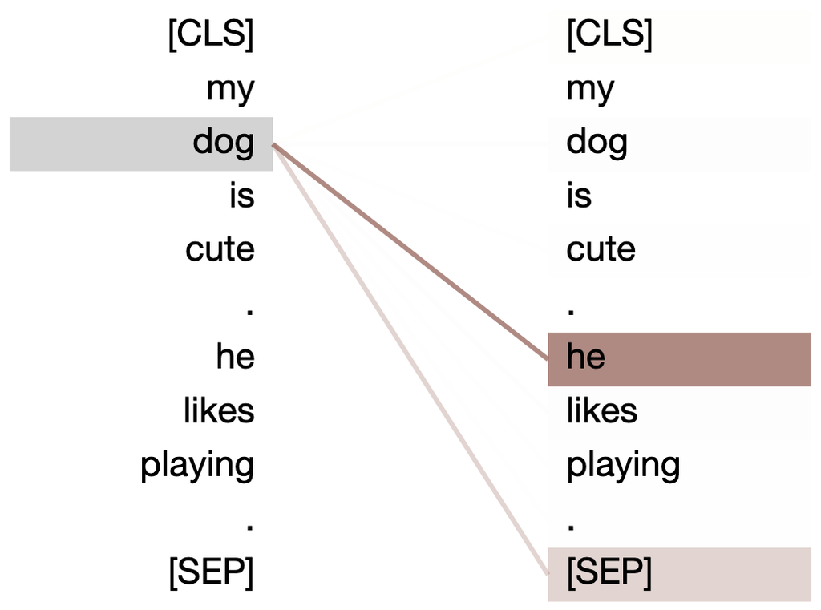

My dog is cute.  
He likes playing.

Update **dog** using information from other input positions.

Weighted values → **contextual representation**.

[BertViz](https://github.com/jessevig/bertviz) · bert-base-uncased, layer 5 / head 5 (zero-based) · [Vaswani et al. (2017), §3.2](https://papers.neurips.cc/paper/7181-attention-is-all-you-need).

← / → Follow the attention links

## Read the connections at dog

**BERT can use every input position.**  
Learned matching scores set the mixing weights.

| Position | Approx. weight | What is being mixed |
| --- | --- | --- |
| **he** | 0.69 | Information from the position at he |
| **[SEP]** | 0.26 | Information from this input’s final marker |
| Other 9 positions | 0.05 total | Information from the remaining positions |

**Darker line → larger mixing weight.**

These weights alone do not prove that **he** refers to **dog**.

[BertViz](https://github.com/jessevig/bertviz) · bert-base-uncased, layer 5 / head 5 (zero-based), updating dog · rounded weights from the same model run · [Vaswani et al. (2017), §3.2](https://papers.neurips.cc/paper/7181-attention-is-all-you-need).

← / → Read the attention connections

## Queries, keys and values make attention concrete

One selected BERT head · update the representation at **dog**.

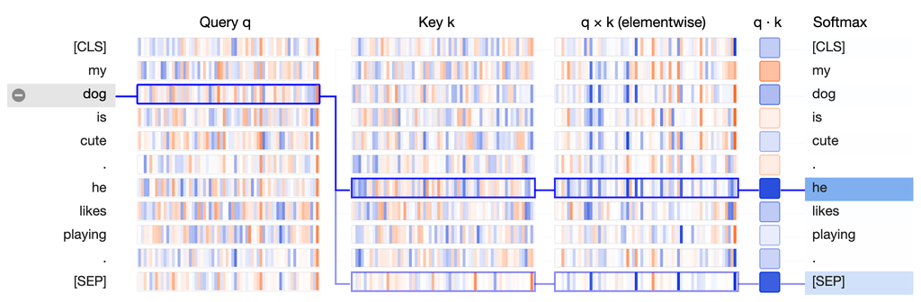

Attention weights → weighted sum of **V** → updated vector at **dog**.

[BertViz neuron view](https://github.com/jessevig/bertviz) · bert-base-uncased, layer 5 / head 5 (zero-based) · [Vaswani et al. (2017), §3.2](https://papers.neurips.cc/paper/7181-attention-is-all-you-need).

← / → Follow self-attention

## An encoder repeats this processing

**Start with token and position representations.**

1**Mix positions**Multi-head self-attention → residual addition → LayerNorm

→

2**Transform each position**Feed-forward network → residual addition → LayerNorm

→

3**Pass to the next layer**Repeat with that layer’s learned parameters

Each sublayer: **LayerNorm(x + Sublayer(x))**

The residual path adds the sublayer’s input back to its output.

[Vaswani et al. (2017), §3.1, Figure 1 and §3.3](https://papers.neurips.cc/paper/7181-attention-is-all-you-need). Normalization order varies across Transformer architectures.

← / → Follow the encoder layer

## Pretraining learns reusable representations

The government announced a [MASK] policy.

**Masked language modeling:** predict selected hidden tokens from context.

The original text supplies the answers.

The model still needs a connection to **our research labels**.

Grimmer, Roberts & Stewart (2022), *Text as Data*, §8.5, p. 88 · [BERT, §3.1](https://aclanthology.org/N19-1423/). Masked-policy sentence: teaching example.

← / → Follow the pretraining example

## Fine-tuning connects representations to labels

[figure not shown]

At inference, the trained model predicts labels for new texts.

[BERT, Figure 1 and §3.2](https://aclanthology.org/N19-1423/).

## Separate fitting, model choice and evaluation

| Split | Purpose | Example decision |
| --- | --- | --- |
| Training | Fit model parameters | Learn from human labels |
| Validation | Choose settings | Select a checkpoint or threshold |
| Test | Estimate performance after choices are fixed | Report held-out results |

Split by **speaker, document or time** when the research setting requires it.

← / → Follow the data splits

## Application 1 · Transformer classification

| Case | Application | Journal |
| --- | --- | --- |
| **Case 1 · Liao & Tang** | Legislative oversight and electoral reform | *Electoral Studies* |
| **Case 2 · Schöll et al.** | Citizen feedback and gender-issue attention | *American Journal of Political Science* |
| **Case 3 · Bestvater & Monroe** | Sentiment versus target-specific stance | *Political Analysis* |

[Liao & Tang (2026)](https://doi.org/10.1016/j.electstud.2025.103026) · [Schöll et al. (2024)](https://doi.org/10.1111/ajps.12772) · [Bestvater & Monroe (2023)](https://doi.org/10.1017/pan.2022.10).

## Case 1 · Targeted oversight

Case 1

[figure not shown]

- **Background**  
  Did Taiwan’s electoral reform change legislators’ local oversight?
- **Classification**  
  Chinese BERT identifies geographically targeted questions (GTQs). Validate on human-coded questions.
- **Research use**  
  Aggregate GTQ shares by legislator-year to study change after reform.

Liao & Tang (2026), *Electoral Studies* 99:103026, §§4–5. [Article](https://doi.org/10.1016/j.electstud.2025.103026). Original first-page excerpt.

← / → Background → Classification → Research use

## Case 1 · Build the oversight measure

Case 1

**Learn the label from legislation**

7,216 human-labeled proposals and amendments → Chinese BERT

**Check the new text genre**

About 400 human-coded written questions · GTQ F1 **.88**

**Turn question labels into a research outcome**

63,748 questions · 402 district legislators · 1999–2019

GTQ percentage = 100 × targeted questions / all questions, **within each legislator-year**.

[Liao & Tang (2026), §4.1 and footnote 9, pp. 4–5; §§5.1–5.2, pp. 6–7](https://doi.org/10.1016/j.electstud.2025.103026). Published classification and measurement design.

← / → Labels → Validation → Research outcome

## Case 1 · Read the reform comparison

Case 1

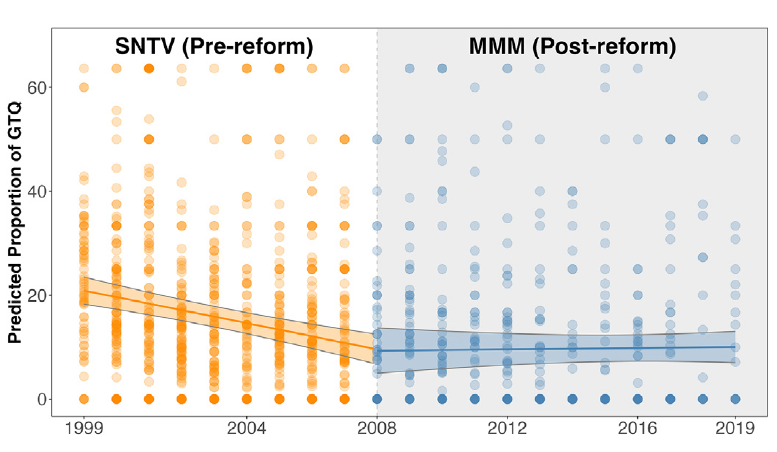

**The initial GTQ share is lower after reform; the negative difference weakens over time.**

[Liao & Tang (2026), Figure 3, p. 7; Table 1, p. 6](https://doi.org/10.1016/j.electstud.2025.103026). Original figure; Model 4 fitted trends and 95% confidence intervals. Interpret with the time comparison and controls.

← / → Axes → Reform boundary → Later trend

## Case 2 · Feedback and issue attention

Case 2

[figure not shown]

- **Background**  
  Do politicians give more attention to issues that received positive feedback?
- **Classification**  
  Fine-tune BERT to identify gender-related tweets. Check precision and recall.
- **Research use**  
  Relate earlier retweet feedback to later shares of gender-related tweets.

Schöll, Gallego & Le Mens (2024), *AJPS* 68(2):557–574, “Measuring Attention to Gender Issues” and Table 4. [Article](https://doi.org/10.1111/ajps.12772). Original first-page excerpt.

← / → Background → Classification → Research use

## Case 2 · Build the issue-attention measure

Case 2

| Stage | What enters the research measure? |
| --- | --- |
| Human labels and BERT | About **20,000 tweets** coded as gender issue / other |
| Validation | Precision **.90** · recall **.79** |
| Aggregation | Gender-related tweets / all tweets, **for each politician-month** |

**BERT supplies the topic label; retweets supply the feedback measure.**

Earlier relative feedback → Later issue-attention share

[Schöll, Gallego & Le Mens (2024), “Measuring Attention to Gender Issues,” p. 562; research variables, pp. 564–565](https://doi.org/10.1111/ajps.12772). Scores are reported for validation data; no separate untouched test set is established in the main-text description.

← / → Human labels → Validation → Panel measure

## Case 2 · Read the feedback estimates

Case 2

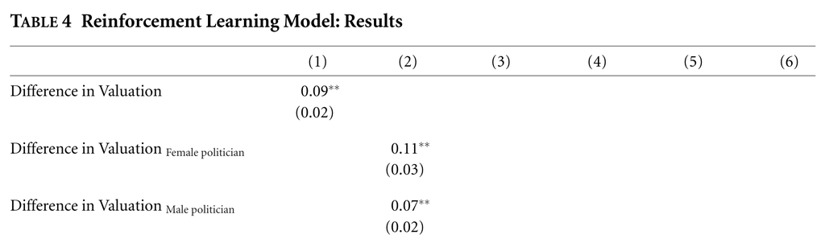

**Both coefficients are positive: .11 for women and .07 for men.**

Their response difference is **not statistically clear**.

Panel association; retweet feedback does not represent all voters’ preferences.

[Schöll et al. (2024), Table 4, p. 567; interpretation, p. 568](https://doi.org/10.1111/ajps.12772). Original table excerpt; logit coefficients, not percentage-point effects. SE clustered by politician.

← / → Estimates → Comparison → Inference limit

## Case 3 · Sentiment is Not Stance

Case 3

[figure not shown]

- **Background**  
  A positive tone and support for a specified target are different labels.
- **Classification**  
  Compare a sentiment dictionary, fine-tuned BERT stance and human coding.
- **Research use**  
  Compare their Women’s March approval measures against political ideology.

Bestvater & Monroe (2023), *Political Analysis* 31(2):235–256, Table 2 and Figure 3. [Article](https://doi.org/10.1017/pan.2022.10). Original first-page excerpt.

← / → Background → Classification → Research use

## Three ways to measure approval

Case 3

**Target: approval of the 2017 Women’s March**

Regress each approval measure on the author’s political ideology.

| Approval measure | Label source | Ideology slope | N |
| --- | --- | --- | --- |
| VADER | Sentiment dictionary + rules | −0.35 | 928 |
| BERT | Fine-tuned on human stance labels | −0.76 | 1,501 |
| Human coding | Manual approval / opposition labels | −1.87 | 1,501 |

**A more negative slope means a sharper decline with conservatism.**

Logit coefficients, not percentage-point changes. Estimation samples differ.

Bestvater & Monroe (2023), pp. 238–242; Table 2, p. 241. [Article](https://doi.org/10.1017/pan.2022.10). Published observational results; human coding is the reference measure.

← / → Dictionary → Fine-tuned BERT → Human reference

## Approval and political ideology

Case 3

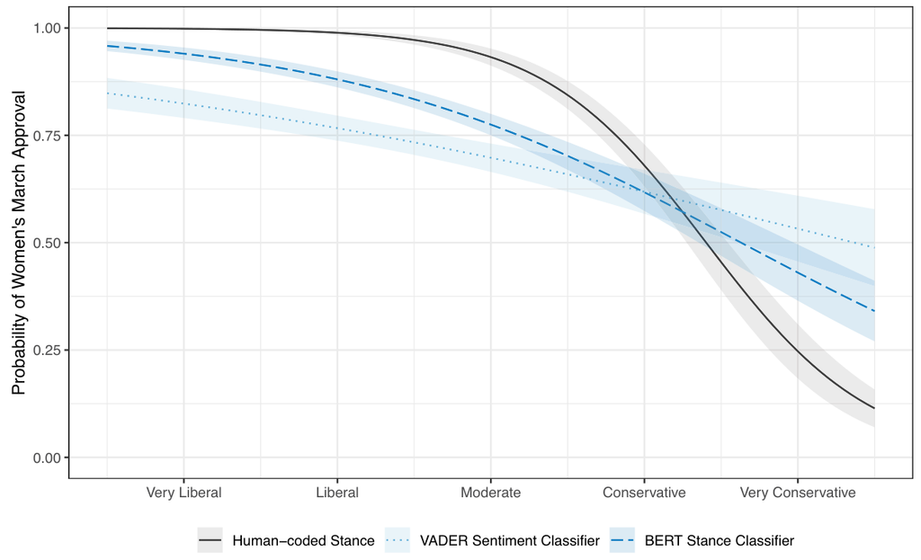

Bestvater & Monroe (2023), Table 2, p. 241; original Figure 3, p. 242 (CC BY 4.0). [Article](https://doi.org/10.1017/pan.2022.10). Regression-estimated approval probabilities, not classifier confidence or causal effects.

← / → Human reference → Fine-tuned BERT → Dictionary

## Application 2 · NLI with Transformers

Text + full hypothesis → Transformer NLI model → Relation scores

| Paired input | Teaching example |
| --- | --- |
| Text | “The council discussed the housing bill today.” |
| Hypothesis | “The council approved the housing bill today.” |

**Natural language inference (NLI)** predicts whether the text entails, contradicts or leaves the hypothesis unresolved.

The hypothesis is part of the input. The model still uses a **Transformer**.

Constructed teaching pair, not a model prediction. [Bowman et al. (2015), §2.1](https://aclanthology.org/D15-1075/) · [Laurer et al. (2024)](https://doi.org/10.1017/pan.2023.20).

← / → Follow the paired input

## Three NLI relations

**Hypothesis:** “The council approved the housing bill today.”

| Relation | Text | What follows? |
| --- | --- | --- |
| **Entailment** | “Today, the council voted to approve the housing bill.” | The hypothesis is supported. |
| **Contradiction** | “The council did not approve the housing bill today.” | The text conflicts with the hypothesis. |
| **Neutral** | “The council discussed the housing bill today.” | Approval remains unresolved. |

**NLI neutral means insufficient evidence about this hypothesis.**

Constructed teaching examples, not model predictions. Relation definitions: [Bowman et al. (2015), §2.1 and Figure 1](https://aclanthology.org/D15-1075.pdf).

← / → Compare the three relations

## From NLI relations to stance labels

| Candidate stance | Full hypothesis |
| --- | --- |
| Support | “The author supports this bill.” |
| Oppose | “The author opposes this bill.” |

**Text + each hypothesis → Relation scores → Decision rule → Stance label**

Define how to compare scores and handle uncertain cases.

- Not entailed does not establish opposition.
- NLI neutral is not automatically neutral stance.
- Validate the rule against human labels.

Constructed stance hypotheses, not model predictions. [Burnham (2025), §§3.2.1–3.2.3, pp. 619–620](https://doi.org/10.1017/psrm.2024.35).

← / → Build the classification rule

## Task-specific classification and NLI

**Same text:** “I oppose Trump’s policies.”

**Task-specific classifier**

Input: the tweet.

Fine-tune on human stance labels for this task.

Predict a class from the trained label set.

**Existing NLI classifier**

Input: the tweet + a stance hypothesis.

Reuse a model trained on NLI relations.

Compare hypotheses to select a stance.

**Both use Transformers.** This NLI example skips target-task fitting; both approaches still need human validation.

Constructed tweet. Zero-shot route follows [Burnham’s official NLI tutorial](https://github.com/MLBurnham/stance_detection_tutorials/blob/main/Zero-shot_stance_detection.ipynb) and its [Hugging Face model](https://huggingface.co/MoritzLaurer/DeBERTa-v3-large-mnli-fever-anli-ling-wanli).

← / → Compare the two inputs

## Stance hypotheses for one tweet

**Text:** “I oppose Trump’s policies.”

**Template:** `The author of this tweet {} Trump.`

| Candidate text | Complete hypothesis |
| --- | --- |
| `supports` | The author of this tweet supports Trump. |
| `opposes` | The author of this tweet opposes Trump. |
| `does not express an opinion about` | The author of this tweet does not express an opinion about Trump. |

**Compare the hypotheses, then check the text.** “No opinion” is a stance candidate; NLI neutral is a relation.

Constructed tweet; no model prediction shown. Template and candidates from [Burnham’s official NLI tutorial](https://github.com/MLBurnham/stance_detection_tutorials/blob/main/Zero-shot_stance_detection.ipynb). [Hugging Face model card](https://huggingface.co/MoritzLaurer/DeBERTa-v3-large-mnli-fever-anli-ling-wanli).

← / → Read the complete hypotheses

## NLI for political text classification

Application 2 · NLI · Study 1 / 2

[figure not shown]

- **Background**  
  Codebooks define categories, but labeled training data are limited.
- **NLI application**  
  Pair texts with category statements; add NLI training, then target-task fine-tuning.
- **Research use**  
  Classify new political texts and evaluate against held-out human labels.

[Laurer et al. (2024), “Less Annotating, More Classifying,” Political Analysis 32:84–100](https://doi.org/10.1017/pan.2023.20). Eight tasks from five datasets; original first-page excerpt.

← / → Follow the study

## Read a stance classification

Application 2 · NLI · Study 1 / 2

**Text in the paper’s Figure 1:** “Our armed forces keep us safe”

| Shown candidate hypothesis | Entailment score in Figure 1 |
| --- | --- |
| “The Military is good” | **.83** |
| “The Military is bad” | .07 |

**Selected label in the figure: Military: Positive**

Compare the candidate hypotheses, then use the selected stance label.

[Laurer et al. (2024), Figure 1, p. 89](https://doi.org/10.1017/pan.2023.20). Paper illustration of the NLI workflow, not a new classroom prediction or accuracy estimate.

← / → Text → Hypotheses → Stance label

## Evaluate labeling efficiency

Application 2 · NLI · Study 1 / 2

| Comparison in the paper | Reported evidence |
| --- | --- |
| **100–2,500 target-task labels** | BERT-NLI gains **10.7–18.3 macro-F1 points** over TF-IDF classifiers, averaged across **8 tasks**. |
| **500 labels** for BERT-NLI vs. **~5,000** for classical methods | Similar average macro-F1; the larger samples are available for **4 datasets**. |

**These labeled-data gains include target-task fine-tuning.**

Required annotation still depends on the task. Evaluate on held-out human labels.

[Laurer et al. (2024), Figure 2, p. 93; Figure 3, p. 94; comparison and footnote 13, p. 95](https://doi.org/10.1017/pan.2023.20). Published results; no new model run.

← / → Read the evidence and its limits

## NLI for stance detection

Application 2 · NLI · Study 2 / 2

[figure not shown]

- **Background**  
  Stance depends on a target, a proposition and context.
- **NLI application**  
  Pair COVID-19 tweets with topic-matched hypotheses; use an existing DeBERTaV3 NLI model.
- **Research use**  
  Aggregate threat-minimizing tweets per user and compare political associations.

[Burnham (2025), “Stance detection: a practical guide to classifying political beliefs in text,” PSRM 13:611–628](https://doi.org/10.1017/psrm.2024.35). Original first-page excerpt, CC BY 4.0; online publication in 2024.

← / → Follow the study

## Classify and validate COVID-19 tweets

Application 2 · NLI · Study 2 / 2

**862,923 COVID-19 tweets · 23,476 users**

September 2020–February 2021

**Tweet + topic-matched hypotheses → DeBERTaV3 NLI**

Flag threat minimization when a matched threat-minimizing hypothesis is entailed.

**Check 300 human-labeled tweets**

| Hypothesis set | MCC | Accuracy |
| --- | --- | --- |
| Set 1 | **.67** | **87%** |
| Set 2 | **.74** | **90%** |

The references came from the original training pool.

[Burnham (2025), §§4.1–4.2, pp. 624–625](https://doi.org/10.1017/psrm.2024.35). Published hypothesis checks; these are not new W10 predictions.

← / → Data → NLI rule → Human check

## Use stance labels in political analysis

Application 2 · NLI · Study 2 / 2

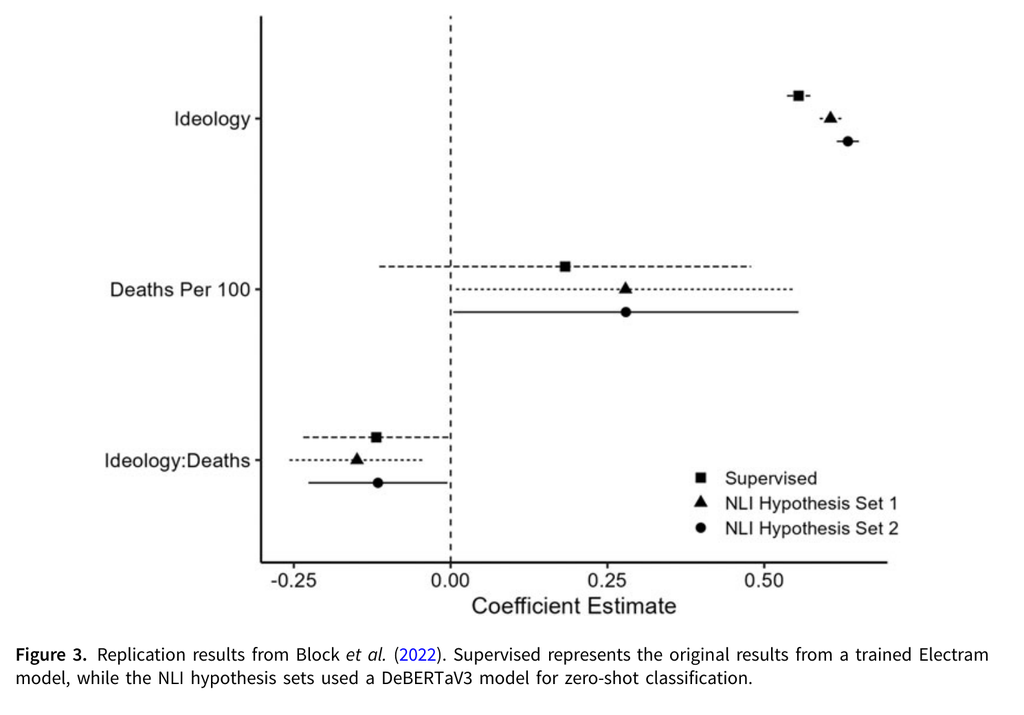

**Tweet labels → User counts → Negative-binomial regression**

Similar associations across label sets do not replace human validation.

[Burnham (2025), Figure 3, p. 624 and §4.2, pp. 624–625](https://doi.org/10.1017/psrm.2024.35). Original figure excerpt, CC BY 4.0; published observational associations, not new or causal W10 estimates.

← / → Labels → Research variable → Analysis

## NLI training and validation choices

| Design choice | Laurer · Political Analysis | Burnham · PSRM |
| --- | --- | --- |
| Research output | Political text categories | COVID-19 threat-minimization labels |
| Target-task fine-tuning | Yes | No in this application |
| Human check | Held-out target-task labels | 300 tweets from the original training pool |

**NLI does not automatically mean zero-shot.**

Both applications require explicit category definitions and a validated decision rule.

[Laurer et al. (2024), pp. 90–94](https://doi.org/10.1017/pan.2023.20) · [Burnham (2025), §§4.1–4.2, pp. 624–625](https://doi.org/10.1017/psrm.2024.35). These are different tasks, not a model ranking.

← / → Compare the design choices

## Lab

LAB · Supplied notebooks

**First: fine-tune policy classifiers. Then: reuse NLI for stance.**

Policy labels → Fine-tuning → Evaluation → NLI stance exercise

Start with the supplied **Flair** and **Transformers** workflows. Finish with the **NLI demonstration**.

Open the `notebooks/` folder with the data directory beside both files.

Lab guide · Flair notebook · Transformers notebook.

## Two APIs, one classification task

LAB · Flair and Transformers

| Open | Main objects | Encoder in the original file |
| --- | --- | --- |
| **Flair notebook** | `Sentence` → `Corpus` → `TextClassifier` | Multilingual DistilUSE |
| **Transformers notebook** | Tokenizer → DistilBERT → `Trainer` | English DistilBERT |

**Same supplied data:** 1,880 train · 627 validation · 627 test.

Read the `text` and `label` columns. Keep the existing split.

**Different encoders and training recipes.** Record both before comparing scores.

Liao & Müller (2024), supplied notebook files. Flair · Transformers · Data and labels · Before running.

← / → Follow the notebook route

## Follow labels through fitting and evaluation

LAB · Shared workflow

**1. Read and attach the supplied labels**

Flair adds a label to each `Sentence`; Transformers maps class names to IDs.

**2. Build the classifier and fit it on train**

Flair uses `ModelTrainer`; Transformers uses `Trainer`. Validation guides model selection.

**3. Evaluate after fixing the training procedure**

Read the final test report and return to the full text of one error.

Flair reading route · Transformers reading route.

← / → Follow the classification workflow

## Read class-specific performance

LAB · Results and interpretation

**Only 44 of 627 test excerpts are labeled environmental policy.**

Accuracy alone can hide a model that misses this class.

**Read precision, recall and F1 by class.**

Compare them with macro-F1 and accuracy where reported.

**Explain one prediction with its full text.**

Report the reference label, prediction and evidence for your interpretation.

Read the results and exit questions · Supplied split counts. Original notebook output cells are historical records.

← / → Read the evidence

## Packages and shared imports

LAB · Shared setup

```bash
python -m pip install \
  torch datasets numpy pandas scikit-learn \
  flair transformers accelerate sentencepiece
```

```python
from importlib.metadata import version
from collections import Counter

import pandas as pd
import torch
from datasets import DatasetDict
from sklearn.metrics import classification_report
```

**1. Install once**

Use the prepared environment. In a notebook, install with `%pip`, then restart the kernel.

**2. Load the shared tools**

`DatasetDict` loads data. `Counter` counts labels. `classification_report` reads performance by class.

Unified Lab guide. Code follows the supplied notebook workflows.

← / → Follow the code and explanation

## Versions and available devices

LAB · Shared setup

```python
packages = [
    "torch", "datasets", "numpy", "pandas",
    "scikit-learn", "flair",
    "transformers", "accelerate",
]
for package in packages:
    print(f"{package}: {version(package)}")
```

```python
if torch.cuda.is_available():
    device = torch.device("cuda")
elif torch.backends.mps.is_available():
    device = torch.device("mps")
else:
    device = torch.device("cpu")
print("Available device:", device)
```

**1. Record the environment**

Keep these package versions with your model settings and results.

**2. Inspect the device**

Choose CUDA, Apple MPS or CPU. Check the device reported by each training log.

Unified Lab guide. Code follows the supplied notebook workflows.

← / → Follow the code and explanation

## Read the current preparation check

LAB · Printed results

```
torch: 2.2.2
datasets: 2.19.0
numpy: 1.26.2
pandas: 2.2.1
scikit-learn: 1.3.2
flair: 0.13.1
transformers: 4.54.0
accelerate: 1.9.0
```

```
Available device: cpu
```

**Preparation check: 27 November 2026.**

**1. Record the versions**

These versions describe the prepared environment.

**2. Read the device**

This check reports CPU availability. Check the trainer log when training.

**3. Keep the date with the output**

This preparation check does not report a trained model’s performance.

Current preparation output, 27 November 2026: environment.txt. This is not the environment record of the original 2024 model run.

← / → Read the printed output

## The shared dataset and label IDs

LAB · Shared setup

```python
dataset = DatasetDict.load_from_disk(
    "irish_environmental_policies"
)
train = dataset["train"]
validation = dataset["validation"]
test = dataset["test"]
```

```python
labels = train.features["label"].names
id2label = {
    i: name for i, name in enumerate(labels)
}
label2id = {
    name: i for i, name in id2label.items()
}
```

**1. Load the existing split**

Run from `notebooks/`. Keep train, validation and test in their supplied roles.

**2. Read the stored mapping**

`0` means other policy. `1` means environmental policy. Preserve this order.

Unified Lab guide. Code follows the supplied notebook workflows.

← / → Follow the code and explanation

## Class counts and a full training text

LAB · Shared setup

```python
rows = []
for split_name, split in dataset.items():
    counts = Counter(split["label"])
    rows.append({
        "split": split_name,
        "rows": len(split),
        "other_policy": counts[0],
        "environmental_policy": counts[1],
    })
print(pd.DataFrame(rows).to_string(index=False))
print(id2label)
```

```python
example = train[0]
print(example["text"])
print("Reference:", id2label[example["label"]])
```

**1. Inspect class balance**

Split sizes: 1,880 / 627 / 627. Test has 44 environmental-policy texts.

**2. Read before fitting**

The first text discusses community policing and has reference label `0`.

Unified Lab guide. Code follows the supplied notebook workflows.

← / → Follow the code and explanation

## Printed data and labels

LAB · Printed results

**Printed from the supplied data · 27 November 2026**

| Split | Rows | Other policy (`0`) | Environmental policy (`1`) |
| --- | --- | --- | --- |
| Train | **1,880** | 1,772 | 108 |
| Validation | **627** | 582 | 45 |
| Test | **627** | 583 | **44** |

`0` → `None Environment Policy`  
`1` → `Environment Policy`

**Only 44 of 627 test excerpts have the environmental-policy label.**

Executed data printout · Supplied dataset counts; original Transformers notebook, zero-based cell 8 (mapping); Flair notebook, cells 12 and 19 (training and test labels).

← / → Counts → Labels → Class balance

## Flair objects and device

LAB · Flair

```python
import flair
from flair.data import Sentence, Corpus
from flair.embeddings import (
    TransformerDocumentEmbeddings,
)
from flair.models import TextClassifier
from flair.trainers import ModelTrainer
```

```python
flair.set_seed(42)
flair.device = device
```

**1. Load the Flair interface**

`Sentence` holds one text. `Corpus` holds the split. The classifier and trainer have separate jobs.

**2. Configure the run**

Set a seed and assign the device to Flair explicitly.

Unified Lab guide. Code follows the supplied notebook workflows.

← / → Follow the code and explanation

## Texts become labeled Sentences

LAB · Flair

```python
def as_sentences(split):
    sentences = []
    for row in split:
        sentence = Sentence(row["text"])
        sentence.add_label(
            "label", str(row["label"])
        )
        sentences.append(sentence)
    return sentences
```

```python
flair_train = as_sentences(train)
flair_dev = as_sentences(validation)
flair_test = as_sentences(test)

print(flair_train[0].to_plain_string())
print(flair_train[0].get_label("label").value)
```

**1. Attach the supplied label**

`Sentence` stores text. `add_label` stores the gold value in the `label` layer.

**2. Preserve each split**

Convert train, validation and test separately, then inspect the first training example.

Unified Lab guide. Code follows the supplied notebook workflows.

← / → Follow the code and explanation

## Corpus and training-label dictionary

LAB · Flair

```python
corpus = Corpus(
    train=flair_train,
    dev=flair_dev,
    test=flair_test,
)
```

```python
label_dict = corpus.make_label_dictionary(
    label_type="label",
    add_dev_test=False,
    min_count=-1,
    add_unk=False,
)
print(label_dict.get_items())
```

**1. Keep the split together**

`Corpus` holds train, dev and test. Their roles remain distinct.

**2. Build classes from train**

`add_dev_test=False` excludes held-out labels. The dictionary contains strings `"0"` and `"1"`.

Unified Lab guide. Code follows the supplied notebook workflows.

← / → Follow the code and explanation

## The Flair encoder and task head

LAB · Flair

```python
flair_checkpoint = (
    "sentence-transformers/"
    "distiluse-base-multilingual-cased-v2"
)
flair_embeddings = TransformerDocumentEmbeddings(
    flair_checkpoint,
    fine_tune=True,
)
```

```python
flair_classifier = TextClassifier(
    flair_embeddings,
    label_dictionary=label_dict,
    label_type="label",
    multi_label=False,
)
```

**1. Load the pretrained encoder**

`fine_tune=True` allows encoder weights to change when training runs.

**2. Add a classification head**

Use the class dictionary and gold label layer. Each text receives one category.

Unified Lab guide. Code follows the supplied notebook workflows.

← / → Follow the code and explanation

## Flair training and the saved checkpoint

LAB · Flair

```python
flair_trainer = ModelTrainer(
    flair_classifier, corpus
)
flair_trainer.train(
    "qta_flair_python_model",
    shuffle=True,
    patience=3,
    learning_rate=0.02,
    mini_batch_size=16,
    max_epochs=3,
    write_weights=True,
    train_with_dev=False,
    train_with_test=False,
    monitor_test=False,
    use_final_model_for_eval=False,
)
```

```python
flair_model = TextClassifier.load(
    "qta_flair_python_model/best-model.pt"
)
```

**1. Run the original training recipe**

SGD, rate `.02`, three epochs. Dev selects the checkpoint. Test runs at the end.

**2. Reload the selected model**

`best-model.pt` contains the checkpoint selected using validation.

Unified Lab guide. Code follows the supplied notebook workflows.

← / → Follow the code and explanation

## Read the original Flair training history

LAB · 2024 notebook record

| Epoch | Train loss | Dev loss | Dev micro-F1 |
| --- | --- | --- | --- |
| 1 | 0.2199 | 0.1576 | 0.9522 |
| 2 | 0.1360 | 0.1586 | 0.9522 |
| 3 | 0.0888 | 0.1616 | 0.9522 |

Values displayed to four decimal places.

**Best checkpoint saved after epoch 1.**

Historical training log: **19 April 2024 · CPU**.

**1. Read the training loss**

Loss falls as the model fits the training data.

**2. Check validation performance**

Dev micro-F1 stays at 0.9522; dev loss rises slightly.

**3. Identify the saved checkpoint**

The log saves epoch 1. Later epochs do not improve the recorded selection score.

Historical output from the supplied 2024 Flair notebook, stored training log. These are original model records, not results from a new W10 training run.

← / → Read the printed output

## Flair predictions and class-specific results

LAB · Flair

```python
flair_model.predict(
    flair_test,
    mini_batch_size=16,
    label_name="predicted",
)
flair_predictions = [
    int(sentence.get_label("predicted").value)
    for sentence in flair_test
]
```

```python
print(classification_report(
    test["label"],
    flair_predictions,
    labels=[0, 1],
    target_names=labels,
    zero_division=0,
))
```

**1. Keep gold and predictions separate**

Write predictions to `predicted`, then convert their strings back to category IDs.

**2. Read the environmental-policy row**

Compare precision, recall and F1. Use the shared class names and order.

Unified Lab guide. Code follows the supplied notebook workflows.

← / → Follow the code and explanation

## Printed Flair test report

LAB · 2024 notebook record

**2024 notebook record · not a new run of revised code**

| Class | Precision | Recall | F1 | Support |
| --- | --- | --- | --- | --- |
| Other policy (`0`) | .9507 | .9914 | .9706 | 583 |
| Environmental policy (`1`) | **.7368** | **.3182** | **.4444** | **44** |

**Accuracy: .9442 · Macro-F1: .7075 · Test rows: 627**

High accuracy can coexist with low environmental-policy recall.

Original Flair notebook, zero-based cell 19, final “Results / By class” output. Stored training recipe: rate .02, batch 16, three epochs.

← / → Larger class → Environmental class → Summary

## Transformers tools and tokenizer

LAB · Transformers

```python
from transformers import (
    AutoTokenizer,
    AutoModelForSequenceClassification,
    TrainingArguments,
    Trainer,
    pipeline,
    set_seed,
)
from sklearn.metrics import (
    accuracy_score,
    f1_score,
)

set_seed(42)
```

```python
hf_checkpoint = "distilbert-base-uncased"
hf_tokenizer = AutoTokenizer.from_pretrained(
    hf_checkpoint
)
```

**1. Make the training components explicit**

Load the tokenizer, model, settings and trainer. Set the seed before model creation.

**2. Match tokenizer and checkpoint**

Use `distilbert-base-uncased` for both the tokenizer and model.

Unified Lab guide. Code follows the supplied notebook workflows.

← / → Follow the code and explanation

## Tokenized data and the DistilBERT head

LAB · Transformers

```python
def tokenize_batch(batch):
    return hf_tokenizer(
        batch["text"],
        padding="max_length",
        truncation=True,
    )

hf_data = dataset.map(tokenize_batch, batched=True)
print(hf_data["train"].column_names)
print(len(hf_data["train"][0]["input_ids"]))
```

```python
hf_model = (
    AutoModelForSequenceClassification
    .from_pretrained(
        hf_checkpoint,
        num_labels=len(labels),
        id2label=id2label,
        label2id=label2id,
    )
)
```

**1. Encode without replacing raw data**

`hf_data` adds input IDs and attention masks. Padding gives 512 positions; truncation limits length.

**2. Use the shared two-class mapping**

Load the pretrained encoder with a new policy-classification head.

Unified Lab guide. Code follows the supplied notebook workflows.

← / → Follow the code and explanation

## Accuracy and macro-F1

LAB · Transformers

```python
def compute_metrics(prediction):
    reference = prediction.label_ids
    predicted = prediction.predictions.argmax(-1)
    return {
        "accuracy": accuracy_score(
            reference, predicted
        ),
        "macro_f1": f1_score(
            reference,
            predicted,
            average="macro",
            zero_division=0,
        ),
    }
```

**1. Define what evaluation reports**

Choose the largest logit for each prediction. Macro-F1 weights the two classes equally.

Unified Lab guide. Code follows the supplied notebook workflows.

← / → Follow the code and explanation

## Training and checkpoint settings

LAB · Transformers

```python
hf_args = TrainingArguments(
    output_dir="./qta_hf_python_model",
    num_train_epochs=3,
    learning_rate=5e-5,
    per_device_train_batch_size=8,
    per_device_eval_batch_size=8,
    eval_strategy="epoch",
    save_strategy="epoch",
    load_best_model_at_end=True,
    metric_for_best_model="macro_f1",
    greater_is_better=True,
    save_total_limit=1,
    report_to="none",
    seed=42,
)
```

**1. Select using validation macro-F1**

Evaluate and save each epoch. Reload the checkpoint with the highest validation macro-F1.

Unified Lab guide. Code follows the supplied notebook workflows.

← / → Follow the code and explanation

## Trainer connects the model and data

LAB · Transformers

```python
hf_trainer = Trainer(
    model=hf_model,
    args=hf_args,
    train_dataset=hf_data["train"],
    eval_dataset=hf_data["validation"],
    processing_class=hf_tokenizer,
    compute_metrics=compute_metrics,
)
hf_trainer.train()
```

**1. Configure first, then train**

Train updates weights. Validation selects the checkpoint. The test split is absent.

Unified Lab guide. Code follows the supplied notebook workflows.

← / → Follow the code and explanation

## Transformers predictions on the test split

LAB · Transformers

```python
hf_result = hf_trainer.predict(hf_data["test"])
hf_predictions = hf_result.predictions.argmax(-1)
print(classification_report(
    hf_result.label_ids,
    hf_predictions,
    labels=[0, 1],
    target_names=labels,
    zero_division=0,
))
```

**1. Evaluate the fixed procedure**

Predict test once the procedure is fixed. Read the same class report as for Flair.

Unified Lab guide. Code follows the supplied notebook workflows.

← / → Follow the code and explanation

## Printed Transformers test report

LAB · 2024 notebook record

**2024 notebook record · not a new run of revised code**

| Stored test metric | Value |
| --- | --- |
| Accuracy | **.9298245614** |
| Macro-F1 | **.4818181818** |
| Macro-precision | .4649122807 |
| Macro-recall | .5000000000 |
| Test rows | 627 |

**The stored cell reports macro averages, not a per-class report.**

Original learning rate: `0.3`. Revised code needs its own run and results.

Original Transformers notebook, zero-based cells 17, 19 and 25. Cells 33–34 use a different model path; the example is not validated by this test report.

← / → Accuracy → Macro averages → Run provenance

## Save and reload the same model directory

LAB · Transformers

```python
model_save_path = "qta_hf_python_model"
hf_trainer.save_model(model_save_path)
hf_tokenizer.save_pretrained(model_save_path)
```

```python
policy_classifier = pipeline(
    "text-classification",
    model=model_save_path,
    tokenizer=model_save_path,
    device=-1,
)
```

**1. Save both model and tokenizer**

Store the selected checkpoint and its matching tokenizer together.

**2. Reload from that path**

The pipeline reads the saved model and tokenizer. `device=-1` runs this demonstration on CPU.

Unified Lab guide. Code follows the supplied notebook workflows.

← / → Follow the code and explanation

## A new policy excerpt

LAB · Transformers

```python
policy_text = (
    "Reducing our carbon footprint through "
    "renewable energy sources and enhanced "
    "energy efficiency is crucial."
)
print(
    policy_classifier(policy_text, truncation=True)
)
```

**1. Read the category and model score**

Use policy text for this policy classifier. The score does not establish correctness.

Unified Lab guide. Code follows the supplied notebook workflows.

← / → Follow the code and explanation

## Align both predictions with the same texts

LAB · Flair and Transformers

```python
comparison = pd.DataFrame({
    "text": test["text"],
    "reference_id": test["label"],
    "flair_id": flair_predictions,
    "transformers_id": hf_predictions,
})
```

```python
for column in [
    "reference_id",
    "flair_id",
    "transformers_id",
]:
    comparison[column.replace("_id", "")] = (
        comparison[column].map(id2label)
    )
```

**1. Join by the unchanged test order**

Keep full text, reference ID and both prediction IDs in one table.

**2. Translate IDs into class names**

Apply the same `id2label` mapping to the reference and both models.

Unified Lab guide. Code follows the supplied notebook workflows.

← / → Follow the code and explanation

## Read a full-text error

LAB · Flair and Transformers

```python
needs_reading = (
    (
        comparison["flair_id"]
        != comparison["reference_id"]
    )
    | (
        comparison["transformers_id"]
        != comparison["reference_id"]
    )
)
candidates = comparison.loc[needs_reading]
row = (
    candidates if len(candidates) else comparison
).iloc[0]
```

```python
print(row["text"])
for name in ["reference", "flair", "transformers"]:
    print(f"{name}: {row[name]}")
```

**1. Choose a text for inspection**

Select a row where either model disagrees with the reference. If none do, use the first text.

**2. Explain the evidence**

Read the full text, reference, Flair prediction and Transformers prediction in that order.

Unified Lab guide. Code follows the supplied notebook workflows.

← / → Follow the code and explanation

## Reuse an existing NLI classifier

LAB · NLI stance demonstration

```python
import torch
from transformers import pipeline

nli_model_id = (
    "MoritzLaurer/DeBERTa-v3-large-"
    "mnli-fever-anli-ling-wanli"
)
nli_revision = (
    "b3546ea6b0346eb6f8d5d68b13c7dc6d0376b3d7"
)
```

```python
nli_classifier = pipeline(
    "zero-shot-classification",
    model=nli_model_id,
    revision=nli_revision,
    device=-1,
    torch_dtype=torch.float32,
    batch_size=1,
)
```

**1. Load an NLI model**

Its existing head predicts relations between two texts.

**2. Reuse its weights**

`device=-1` selects CPU. There is no `train()` call.

NLI Lab guide · Adapted from [Burnham’s official tutorial](https://github.com/MLBurnham/stance_detection_tutorials/blob/main/Zero-shot_stance_detection.ipynb).

← / → Follow the NLI code

## Write the stance hypotheses

LAB · NLI stance demonstration

```python
nli_labels = [
    "supports",
    "opposes",
    "does not express an opinion about",
]
nli_template = (
    "The author of this tweet {} Trump."
)
```

```python
for label in nli_labels:
    print(nli_template.format(label))
```

**1. Define the target**

The template names Trump. Candidate phrases specify the stance.

**2. Read complete statements**

The model pairs each statement with the same input text.

NLI Lab guide · Adapted from [Burnham’s official tutorial](https://github.com/MLBurnham/stance_detection_tutorials/blob/main/Zero-shot_stance_detection.ipynb).

← / → Follow the NLI code

## Classify three short texts

LAB · NLI stance demonstration

```python
nli_texts = [
    "I support Trump's policies.",
    "I oppose Trump's policies.",
    "The committee meets on Tuesday.",
]
```

```python
nli_results = nli_classifier(
    nli_texts,
    candidate_labels=nli_labels,
    hypothesis_template=nli_template,
    multi_label=False,
)
```

**1. Read texts A, B and C**

These are constructed teaching inputs, not a research test set.

**2. Compare candidate scores**

`False` selects one stance. It normalizes across candidate hypotheses.

NLI Lab guide · Adapted from [Burnham’s official tutorial](https://github.com/MLBurnham/stance_detection_tutorials/blob/main/Zero-shot_stance_detection.ipynb).

← / → Follow the NLI code

## Read the executed NLI output

LAB · Executed NLI demonstration · 27 November 2026

**A:** I support Trump’s policies.

**B:** I oppose Trump’s policies.

**C:** The committee meets on Tuesday.

| Text | Support | Oppose | No opinion |
| --- | --- | --- | --- |
| A | 0.9918 | 0.0044 | 0.0038 |
| B | 0.0086 | 0.9843 | 0.0071 |
| C | 0.2063 | 0.1967 | 0.5970 |

Candidate scores with `multi_label=False`; short column names.

**1. A ranks support first**

Read the text and all three scores together.

**2. B ranks opposition first**

Check that the target matches the research definition.

**3. C is less decisive**

No opinion leads at `.5970`. Set review rules with validation data.

Actual CPU output and pinned revision · Constructed inputs; no fine-tuning, COVID-19 replication or accuracy estimate.

← / → Read text A, then B, then C

## Selected application readings

- Liao & Tang (2026). [Electoral Systems and Geographically Targeted Oversight](https://doi.org/10.1016/j.electstud.2025.103026). *Electoral Studies*.
- Schöll, Gallego & Le Mens (2024). [How Politicians Learn from Citizens’ Feedback](https://doi.org/10.1111/ajps.12772). *AJPS*.
- Bestvater & Monroe (2023). [Sentiment is Not Stance](https://doi.org/10.1017/pan.2022.10). *Political Analysis*.
- Laurer et al. (2024). [Less Annotating, More Classifying](https://doi.org/10.1017/pan.2023.20). *Political Analysis*.
- Burnham (2025). [Stance detection: a practical guide](https://doi.org/10.1017/psrm.2024.35). *PSRM*.

Architecture: [Vaswani et al. (2017)](https://papers.neurips.cc/paper/7181-attention-is-all-you-need) · [Devlin et al. (2019)](https://aclanthology.org/N19-1423/). Lab: Liao & Müller (2024), supplied Week 12 notebooks.